# 6 Analysis of longitudinal data

```
Intro from the IODS MOOC-page:
```

After working hard with multivariate, mostly explorative, even heuristic techniques that are common in data science, the last topic of the course will take us back in the task of building **statistical models**.

The new challenge is that the data will include **two types of dependencies simultaneously**: In addition to the correlated variables that we have faced with all models and methods so far, the **observations of the data will also be correlated with each other**.

Usually, we can assume that the observations are not correlated - instead, they are assumed to be *independent* of each other. However, in **longitudinal settings this assumption seldom holds, because we have multiple observations or measurements of the same individuals. The concept of repeated measures highlights this phenomenon that is actually quite typical in many applications. Both types of dependencies (variables and observations) must be taken into account; otherwise the models will be biased**.

To analyze this kind of data sets, we will focus on a single class of methods, called **linear mixed effects models** that can cope quite nicely with the setting described above.

Before we consider two examples of mixed models, namely the random intercept model and the random intercept and slope model, we will learn how to wrangle **longitudinal data in wide form and long form**, take a look at some **graphical displays of longitudinal data**, and try a simple *summary* measure approach that may sometimes provide a useful first step in these challenges. In passing, we “violently” apply the usual “fixed” models (although we know that they are not the right choice here) in order to compare the results and see the consequences of making invalid assumptions.

## 6.1 Graphical displays and summary measure approach

### 6.1.1 Introducing the RATS dataset

> The RATS data is from a nutrition study conducted in three groups of rats (Crowder and Hand, 1990. The three groups were put on different diets, and each animals body weight (grams) was recorded repeatedly approximately weekly over a 9-week period (the weighting day number is given). The most interesting question is whether the growth profiles of the three groups differ.

```r
# Read in the RATS data in wide and long format (L for long)
RATS <- read.table("./data/RATS.txt", header=TRUE)
RATSL <- read.table("./data/RATSL.txt", header=TRUE)
# factor the categorical variables ID and group
RATSL$ID <- as.factor(RATSL$ID)
RATSL$Group <- as.factor(RATSL$Group)
# Look at the WHOLE data in wide format
RATS
```

```
##    ID Group WD1 WD8 WD15 WD22 WD29 WD36 WD43 WD44 WD50 WD57 WD64
## 1   1     1 240 250  255  260  262  258  266  266  265  272  278
## 2   2     1 225 230  230  232  240  240  243  244  238  247  245
## 3   3     1 245 250  250  255  262  265  267  267  264  268  269
## 4   4     1 260 255  255  265  265  268  270  272  274  273  275
## 5   5     1 255 260  255  270  270  273  274  273  276  278  280
## 6   6     1 260 265  270  275  275  277  278  278  284  279  281
## 7   7     1 275 275  260  270  273  274  276  271  282  281  284
## 8   8     1 245 255  260  268  270  265  265  267  273  274  278
## 9   9     2 410 415  425  428  438  443  442  446  456  468  478
## 10 10     2 405 420  430  440  448  460  458  464  475  484  496
## 11 11     2 445 445  450  452  455  455  451  450  462  466  472
## 12 12     2 555 560  565  580  590  597  595  595  612  618  628
## 13 13     3 470 465  475  485  487  493  493  504  507  518  525
## 14 14     3 535 525  530  533  535  540  525  530  543  544  559
## 15 15     3 520 525  530  540  543  546  538  544  553  555  548
## 16 16     3 510 510  520  515  530  538  535  542  550  553  569
```

```r
# Look at the first 24 rows of long format
head(RATSL, 24)
```

```
##    ID Group  WD Weight Time
## 1   1     1 WD1    240    1
## 2   2     1 WD1    225    1
## 3   3     1 WD1    245    1
## 4   4     1 WD1    260    1
## 5   5     1 WD1    255    1
## 6   6     1 WD1    260    1
## 7   7     1 WD1    275    1
## 8   8     1 WD1    245    1
## 9   9     2 WD1    410    1
## 10 10     2 WD1    405    1
## 11 11     2 WD1    445    1
## 12 12     2 WD1    555    1
## 13 13     3 WD1    470    1
## 14 14     3 WD1    535    1
## 15 15     3 WD1    520    1
## 16 16     3 WD1    510    1
## 17  1     1 WD8    250    8
## 18  2     1 WD8    230    8
## 19  3     1 WD8    250    8
## 20  4     1 WD8    255    8
## 21  5     1 WD8    260    8
## 22  6     1 WD8    265    8
## 23  7     1 WD8    275    8
## 24  8     1 WD8    255    8
```

Looking at the datasets above implicitly shows the **difference between the wide and the long format** of data!

> **Wide format**: a subject’s repeated responses will be in a single row and each response is in a separate column

> **Long format**: each row is one time point per subject

The reason for setting the data in one format or the other is usually simply because different analyses require different set ups. But in addition to technical requirements, the each approach has analytical implications, i.e. the wide format emphasizes the subject while the long format emphasizes the measurement occasion.

**Note**! The wide format has 16 observations of 13 variables and the long format 176 observations of 5 variables. Here **the variable `Time` was added to the long format data to directly show the numerical weighting day number** (instead of string “WD1” etc.) for easier plotting.

### 6.1.2 Graphical displays of longitudinal data

According to Diggle et al. (2002), the central idea of the graphical displays of the data is to

- Show as much of the relevant raw data as possible rather than only data summaries
- Highlight aggregate pattern of potential scientific interest
- Identify both cross sectional and longitudinal patterns
- Try to make the identification of unusual individuals or unusual observations simple.

Let’s apply the idea to the `RATS` data.

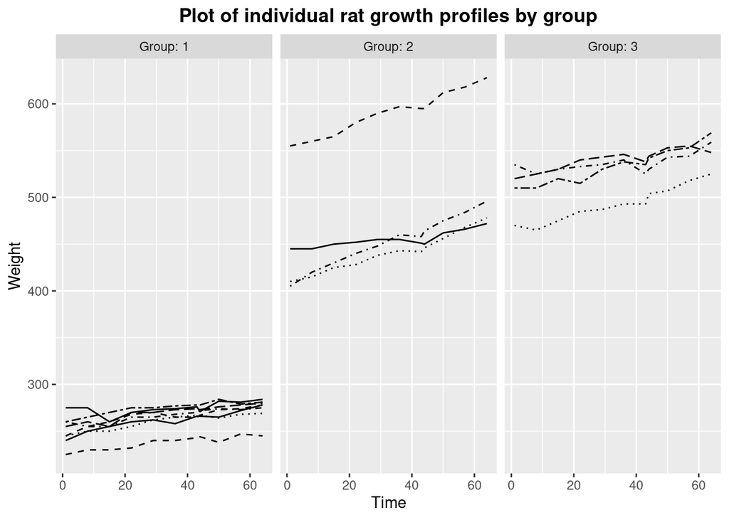

```r
# Access the package ggplot2
library(ggplot2)
library(tidyr)
library(dplyr)
# Draw the plot
ggplot(RATSL, aes(x = Time, y = Weight, linetype = ID)) +
  geom_line() +
  scale_linetype_manual(values = rep(1:10, times=4)) +
  facet_grid(. ~ Group, labeller = label_both) +
  theme(legend.position = "none") +
  scale_y_continuous(limits = c(min(RATSL$Weight), max(RATSL$Weight)))+
  theme(plot.title = element_text(face="bold",hjust=0.5))+labs(title="Plot of individual rat growth profiles by group")
```

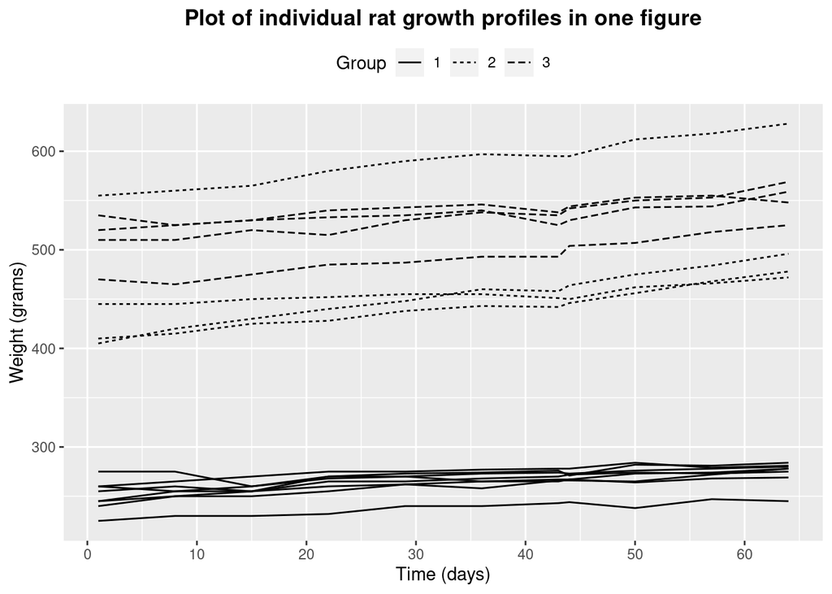

```r
# Plot the RATSL data
ggplot(RATSL, aes(x = Time, y = Weight, group = ID)) +
  geom_line(aes(linetype=Group))+scale_x_continuous(name = "Time (days)", breaks = seq(0, 60, 10))+scale_y_continuous(name = "Weight (grams)")+theme(legend.position = "top",plot.title = element_text(face="bold",hjust=0.5))+labs(title="Plot of individual rat growth profiles in one figure")
```

**Observations from the data**:

With large number of observations, graphical displays of individual re- sponse profiles are of little use and investigators then commonly produce graphs showing **average profiles for each treatment group** along with some indication of the variation of the observations at each time point. Here we provide two alternatives, a *continuous* mean curve as well as a *dicrete* side-by-side boxplot of weights at each timepoint.

```r
# Number of days, baseline (day 1) included
n <- RATSL$Time %>% unique() %>% length()
# Summary data with mean and standard error of RATS by Group and Time
RATSS <- RATSL %>%
  group_by(Group, Time) %>%
  summarise( mean = mean(Weight), se = sd(Weight)/sqrt(n) ) %>%
  ungroup()
# Glimpse the data
glimpse(RATSS)
```

```
## Rows: 33
## Columns: 4
## $ Group <fct> 1, 1, 1, 1, 1, 1, 1, 1, 1, 1, 1, 2, 2, 2, 2, 2, 2, 2, 2, 2, 2, …
## $ Time  <int> 1, 8, 15, 22, 29, 36, 43, 44, 50, 57, 64, 1, 8, 15, 22, 29, 36,…
## $ mean  <dbl> 250.625, 255.000, 254.375, 261.875, 264.625, 265.000, 267.375, …
## $ se    <dbl> 4.589478, 3.947710, 3.460116, 4.100800, 3.333956, 3.552939, 3.3…
```

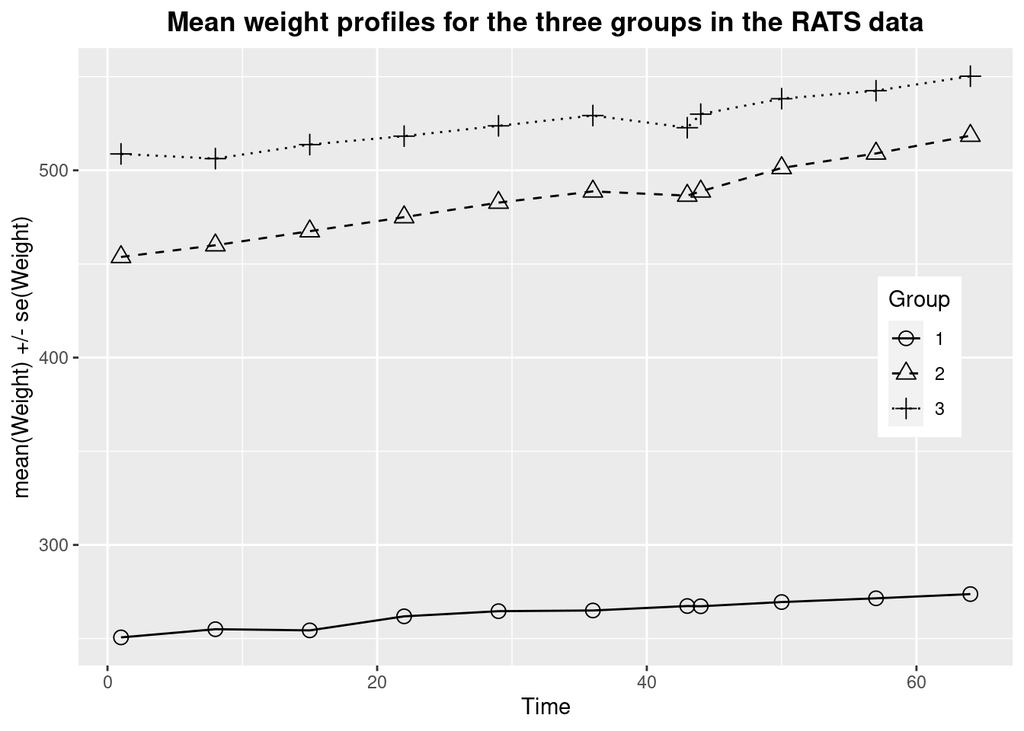

```r
# Plot the mean weight profiles
ggplot(RATSS, aes(x = Time, y = mean, linetype = Group, shape = Group)) +
  geom_line() +
  scale_linetype_manual(values = c(1,2,3)) +
  geom_point(size=3) +
  scale_shape_manual(values = c(1,2,3)) +
  #geom_errorbar(aes(ymin=mean-se, ymax=mean+se, linetype="1"), width=0.3) +
  theme(legend.position = c(0.9,0.5),plot.title = element_text(face="bold",hjust=0.5)) +
  scale_y_continuous(name = "mean(Weight) +/- se(Weight)")+
  labs(title="Mean weight profiles for the three groups in the RATS data")
```

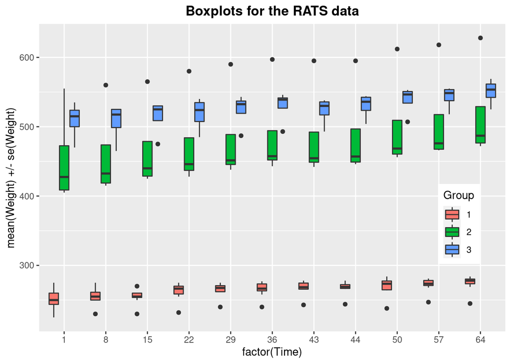

```r
# Boxplots
ggplot(RATSL, aes(x = factor(Time), y = Weight, fill = Group)) +
  geom_boxplot() +
  theme(legend.position = c(0.9,0.35),plot.title = element_text(face="bold",hjust=0.5)) +
  scale_y_continuous(name = "mean(Weight) +/- se(Weight)")+
  labs(title="Boxplots for the RATS data")
```

The discrete side-by-side boxplot gives better insights about data (e.g. outliers). However, the number of subjects is quite small in the groups (8, 4 and 4, respectively) so certain subjects will stand out as the outliers all the time. The boxplots and the average profile plot clearly indicate the general increase in weight over the 60 days in all groups. There is no big overlap suggesting there are differences between groups.

### 6.1.3 Summary measure analysis of longitudinal data

The **summary measure method** (also called the response feature method) **transforms the repeated measurements** of each individual in the study **into a single value** that captures some essential feature of the individuals response over time. Standard univariate methods are then applied to the summary measures created from the sample of subjects.

> “The average response to treatment over time is often likely to be the most relevant summary statistic in treatment trials.” – Frison and Pocock (1992)

Applying the age-old wisdom above, let’s choose the mean of weight at a given day as the summary variable for each group.

```r
# Create a summary data by Group and subject with mean as the summary variable (ignoring baseline Time 1).
RATSL8S <- RATSL %>%
  filter(Time > 1) %>%
  group_by(Group, Time) %>%
  summarise(mean=mean(Weight) ) %>%
  ungroup()
# Glimpse the data
glimpse(RATSL8S)
```

```
## Rows: 30
## Columns: 3
## $ Group <fct> 1, 1, 1, 1, 1, 1, 1, 1, 1, 1, 2, 2, 2, 2, 2, 2, 2, 2, 2, 2, 3, …
## $ Time  <int> 8, 15, 22, 29, 36, 43, 44, 50, 57, 64, 8, 15, 22, 29, 36, 43, 4…
## $ mean  <dbl> 255.000, 254.375, 261.875, 264.625, 265.000, 267.375, 267.250, …
```

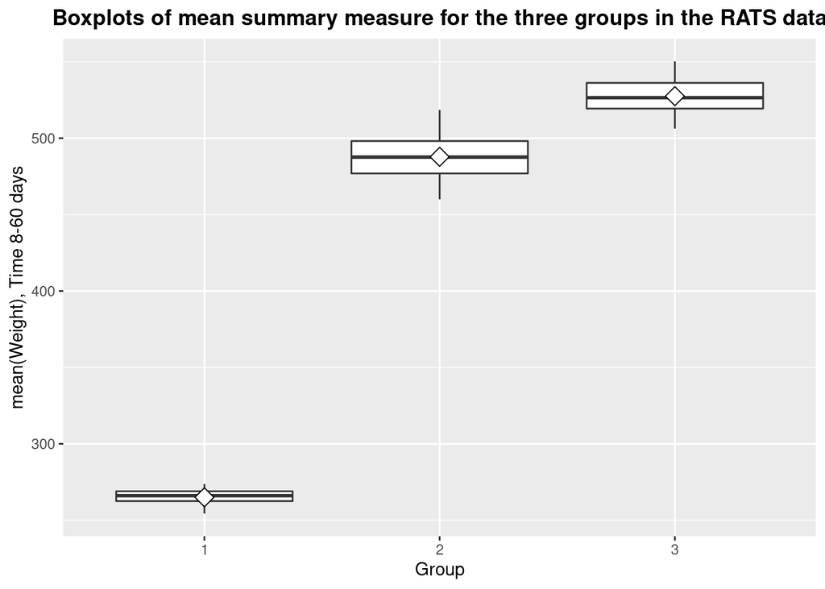

```r
# Draw a boxplot of the mean versus Group
ggplot(RATSL8S, aes(x = Group, y = mean)) +
  geom_boxplot() +
  stat_summary(fun = "mean", geom = "point", shape=23, size=4, fill = "white") +
  scale_y_continuous(name = "mean(Weight), Time 8-60 days")+
  theme(plot.title = element_text(face="bold",hjust=0.5)) +
  labs(title="Boxplots of mean summary measure for the three groups in the RATS data")
```

Group 1 is clearly different from the rest (this comes as no surprise based on the earlier graphical display). Groups 2 and 3 are overlapping a bit, though. There are three groups so two sample t-test is out of the questions. We could try analysis of variance (ANOVA). We are, however, forcing it a bit since the assumptions for ANOVA are

- The observations are obtained independently (not true!) and randomly from the population defined by the factor levels.
- The data of each factor level are normally distributed.
- These normal populations have a common variance.

Well, let’s try ANOVA anyway.

```r
# Add the baseline from the original data as a new variable to the summary data
RATSL8S2 <- RATSL8S %>%
  mutate(baseline = c(rep(RATSS$mean[1],10),rep(RATSS$mean[12],10),rep(RATSS$mean[23],10)))
# Fit the linear model with the mean as the response
fit <- lm(mean ~ baseline + Group, data = RATSL8S2)
# Compute the analysis of variance table for the fitted model with anova()
anova(fit)
```

```
## Analysis of Variance Table
##
## Response: mean
##           Df Sum Sq Mean Sq  F value    Pr(>F)
## baseline   1 398745  398745 2173.475 < 2.2e-16 ***
## Group      1   1582    1582    8.622  0.006713 **
## Residuals 27   4953     183
## ---
## Signif. codes:  0 '***' 0.001 '**' 0.01 '*' 0.05 '.' 0.1 ' ' 1
```

## 6.2 Linear mixed effects models for normal response variables

### 6.2.1 Introducing the BPRS dataset

> The brief psychiatric rating scale (BPRS) was used to evaluate 40 male subjects suspected of having schizophrenia. Subjects were randomly assigned to one of the two treatment groups and each subject was measured on BPRS before treatments (week 0) and then at weekly intervals for eight weeks. The BPRS value is the sum of 18 symptom constructs (e.g. hostility, suspiciousness, hallucination, grandiosity etc.) each of which are rated from one (not present) to seven (extremely severe). The data originates from Davis (2002).

```r
# Read in BPRS data; wide and long versions
BPRS <- read.table("./data/BPRS.txt", header=TRUE)
BPRSL <- read.table("./data/BPRSL.txt", header=TRUE)
# Factor variables ID and Group
BPRSL$subject <- as.factor(BPRSL$subject)
BPRSL$treatment <- as.factor(BPRSL$treatment)
# Look at the wide data
glimpse(BPRS)
```

```
## Rows: 40
## Columns: 11
## $ treatment <int> 1, 1, 1, 1, 1, 1, 1, 1, 1, 1, 1, 1, 1, 1, 1, 1, 1, 1, 1, 1,…
## $ subject   <int> 1, 2, 3, 4, 5, 6, 7, 8, 9, 10, 11, 12, 13, 14, 15, 16, 17, …
## $ week0     <int> 42, 58, 54, 55, 72, 48, 71, 30, 41, 57, 30, 55, 36, 38, 66,…
## $ week1     <int> 36, 68, 55, 77, 75, 43, 61, 36, 43, 51, 34, 52, 32, 35, 68,…
## $ week2     <int> 36, 61, 41, 49, 72, 41, 47, 38, 39, 51, 34, 49, 36, 36, 65,…
## $ week3     <int> 43, 55, 38, 54, 65, 38, 30, 38, 35, 55, 41, 54, 31, 34, 49,…
## $ week4     <int> 41, 43, 43, 56, 50, 36, 27, 31, 28, 53, 36, 48, 25, 25, 36,…
## $ week5     <int> 40, 34, 28, 50, 39, 29, 40, 26, 22, 43, 36, 43, 25, 27, 32,…
## $ week6     <int> 38, 28, 29, 47, 32, 33, 30, 26, 20, 43, 38, 37, 21, 25, 27,…
## $ week7     <int> 47, 28, 25, 42, 38, 27, 31, 25, 23, 39, 36, 36, 19, 26, 30,…
## $ week8     <int> 51, 28, 24, 46, 32, 25, 31, 24, 21, 32, 36, 31, 22, 26, 37,…
```

```r
# Look at the long data
glimpse(BPRSL)
```

```
## Rows: 360
## Columns: 5
## $ treatment <fct> 1, 1, 1, 1, 1, 1, 1, 1, 1, 1, 1, 1, 1, 1, 1, 1, 1, 1, 1, 1,…
## $ subject   <fct> 1, 2, 3, 4, 5, 6, 7, 8, 9, 10, 11, 12, 13, 14, 15, 16, 17, …
## $ weeks     <chr> "week0", "week0", "week0", "week0", "week0", "week0", "week…
## $ bprs      <int> 42, 58, 54, 55, 72, 48, 71, 30, 41, 57, 30, 55, 36, 38, 66,…
## $ week      <int> 0, 0, 0, 0, 0, 0, 0, 0, 0, 0, 0, 0, 0, 0, 0, 0, 0, 0, 0, 0,…
```

The main focus is the variable `bprs`. Similar to the RATS data, we also introduce the data in long format for the analysis. In the process of data wrangling the wide format to long format, the variable `week` was added to indicate week as a simple integer value.

### 6.2.2 Brief graphical display of BPRS

Let’s start by getting a rough idea about the data and not worry too much about the longitudinal nature of the data.

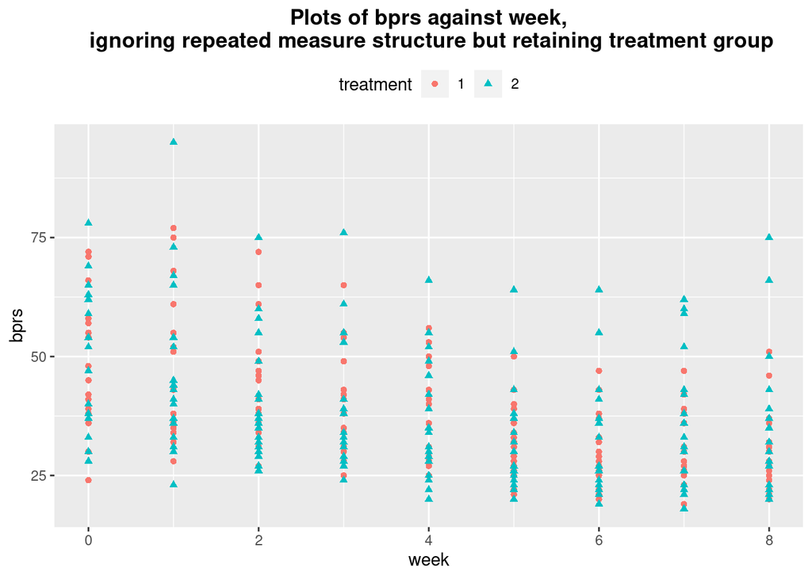

```r
# Draw the plot
ggplot(BPRSL, aes(x = week, y = bprs)) +
  geom_point(aes(shape=treatment,color=treatment)) +
  theme(legend.position = "top",plot.title = element_text(face="bold", hjust=0.5)) +
  scale_y_continuous(limits = c(min(BPRSL$bprs), max(BPRSL$bprs)))+
  labs(title="Plots of bprs against week,\n ignoring repeated measure structure but retaining treatment group")
```

Seems pretty much like a mixed bag! Now, let’s take note of the longitudinal nature by connecting the individual profile points.

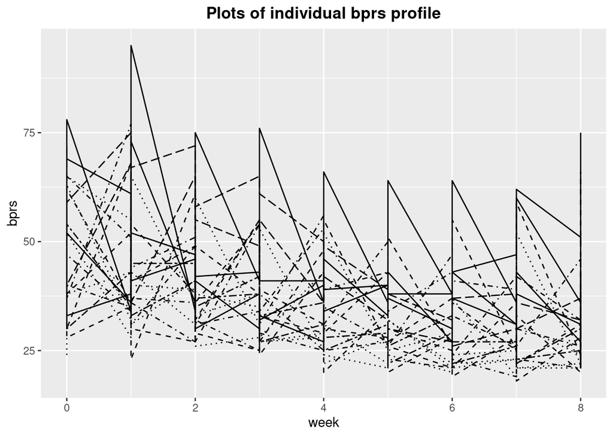

```r
# Draw the plot
ggplot(BPRSL, aes(x = week, y = bprs, linetype = subject)) +
  geom_line() +
  scale_linetype_manual(values = rep(1:10, times=4)) +
  theme(legend.position = "none") +
  scale_y_continuous(limits = c(min(BPRSL$bprs), max(BPRSL$bprs)))+
  theme(plot.title = element_text(face="bold",hjust=0.5)) +
  labs(title="Plots of individual bprs profile")
```

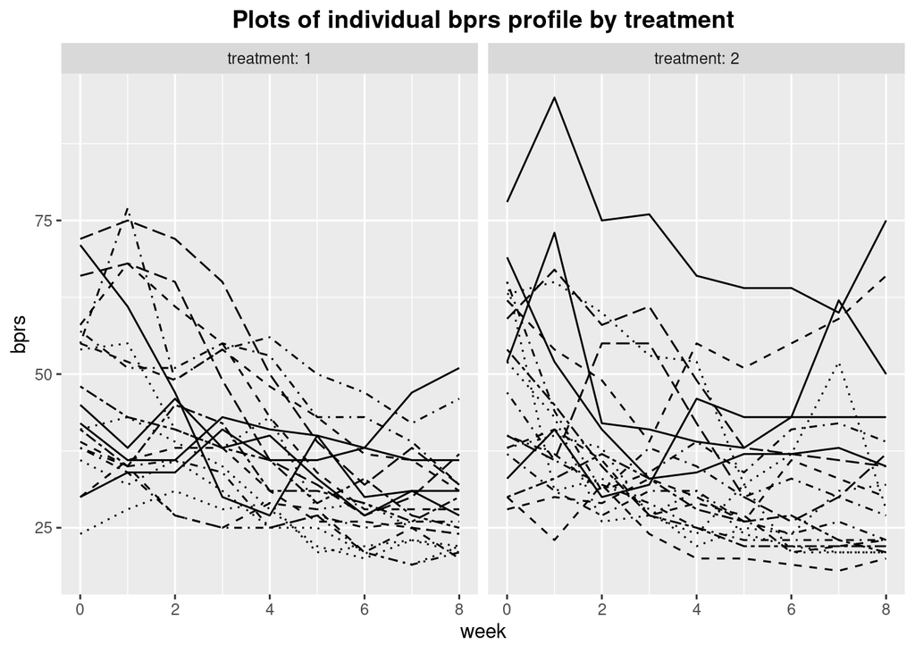

```r
ggplot(BPRSL, aes(x = week, y = bprs, linetype = subject)) +
  geom_line() +
  scale_linetype_manual(values = rep(1:10, times=4)) +
  facet_grid(. ~ treatment, labeller = label_both) +
  theme(legend.position = "none") +
  scale_y_continuous(limits = c(min(BPRSL$bprs), max(BPRSL$bprs)))+
  theme(plot.title = element_text(face="bold",hjust=0.5)) +
  labs(title="Plots of individual bprs profile by treatment")
```

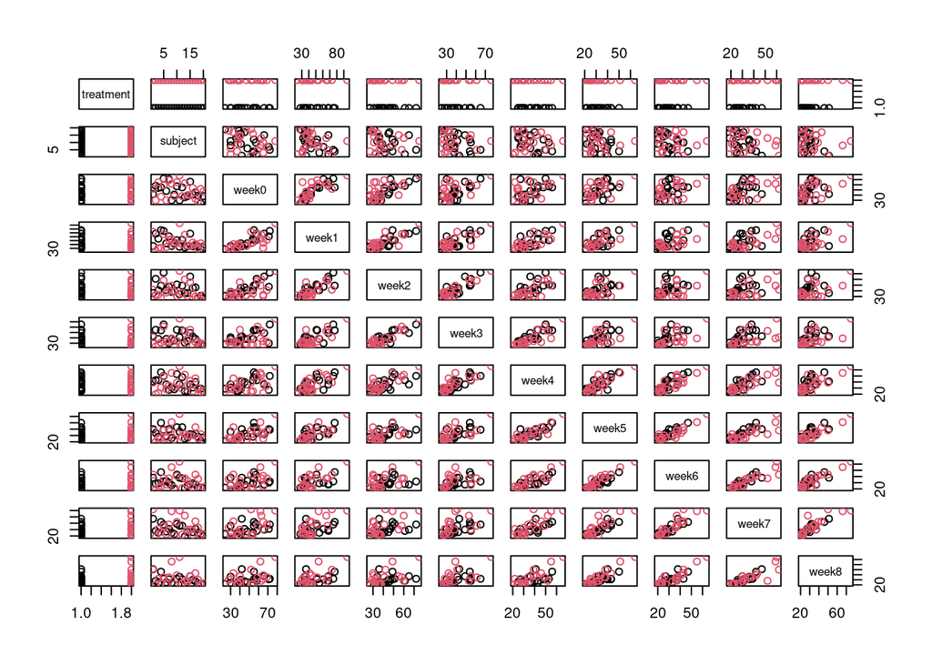

```r
# Try scatterplot matrix, colored by treatment group
pairs(BPRS, col=BPRS$treatment)
```

After connecting the data points for each subject, the plot makes more sense. However, it is still difficult to get any insights from the data. The scatterplot matrix of the repeated measures of bprs is not a terribly helpful addition either, but it does demonstrate that the repeated measures are certainly not independent of one another. What one can say, nevertheless, is that

- the `bprs` value seems to be generally decreasing over the time
- there seems be somewhat much variance in the data of each individual
- the `bprs` values for treatment groups 1 and 2 are overlapping

### 6.2.3 Fitting the linear model

Let’s fit a simple linear model to the BPRS data.

```r
# create a regression model RATS_reg
BPRS_reg <- lm(bprs ~ week + treatment, data=BPRSL)
# print out a summary of the model
summary(BPRS_reg)
```

```
##
## Call:
## lm(formula = bprs ~ week + treatment, data = BPRSL)
##
## Residuals:
##     Min      1Q  Median      3Q     Max
## -22.454  -8.965  -3.196   7.002  50.244
##
## Coefficients:
##             Estimate Std. Error t value Pr(>|t|)
## (Intercept)  46.4539     1.3670  33.982   <2e-16 ***
## week         -2.2704     0.2524  -8.995   <2e-16 ***
## treatment2    0.5722     1.3034   0.439    0.661
## ---
## Signif. codes:  0 '***' 0.001 '**' 0.01 '*' 0.05 '.' 0.1 ' ' 1
##
## Residual standard error: 12.37 on 357 degrees of freedom
## Multiple R-squared:  0.1851, Adjusted R-squared:  0.1806
## F-statistic: 40.55 on 2 and 357 DF,  p-value: < 2.2e-16
```

Deciphering from the summary, the intercept and week (time) are statistically significant variables in the model. Interestingly, however, the treatment group is not! Anyway, this model forms the “*baseline*” against which the next models will be compared.

### 6.2.4 Fitting the random intercept model

While the linear model above assumes independence of the repeated measured of weight, that is not the case in reality. Thus we will next use a random intercept model which **allows the linear regression fit for each subject to differ in *intercept*** from other subjects.

```r
# access library lme4
library(lme4)
# Create a random intercept model
BPRS_ref <- lmer(bprs ~ week + treatment + (1 | subject), data = BPRSL, REML = FALSE)
# Print the summary of the model
summary(BPRS_ref)
```

```
## Linear mixed model fit by maximum likelihood  ['lmerMod']
## Formula: bprs ~ week + treatment + (1 | subject)
##    Data: BPRSL
##
##      AIC      BIC   logLik deviance df.resid
##   2748.7   2768.1  -1369.4   2738.7      355
##
## Scaled residuals:
##     Min      1Q  Median      3Q     Max
## -3.0481 -0.6749 -0.1361  0.4813  3.4855
##
## Random effects:
##  Groups   Name        Variance Std.Dev.
##  subject  (Intercept)  47.41    6.885
##  Residual             104.21   10.208
## Number of obs: 360, groups:  subject, 20
##
## Fixed effects:
##             Estimate Std. Error t value
## (Intercept)  46.4539     1.9090  24.334
## week         -2.2704     0.2084 -10.896
## treatment2    0.5722     1.0761   0.532
##
## Correlation of Fixed Effects:
##            (Intr) week
## week       -0.437
## treatment2 -0.282  0.000
```

Allowing the intercept to vary increases the flexibility (and complexity) of the model. One can see that the Fixed Effects model here is actually the same linear model fit earlier. Let’s increase the flexibility even further.

### 6.2.5 Fitting random intercept and random slope model

In addition to difference in the interecept, let’s **allow also the slopes to differ**.

```r
# create a random intercept and random slope model
BPRS_ref1 <- lmer(bprs ~ week + treatment + (week | subject), data = BPRSL, REML = FALSE)
# print a summary of the model
summary(BPRS_ref1)
```

```
## Linear mixed model fit by maximum likelihood  ['lmerMod']
## Formula: bprs ~ week + treatment + (week | subject)
##    Data: BPRSL
##
##      AIC      BIC   logLik deviance df.resid
##   2745.4   2772.6  -1365.7   2731.4      353
##
## Scaled residuals:
##     Min      1Q  Median      3Q     Max
## -2.8919 -0.6194 -0.0691  0.5531  3.7976
##
## Random effects:
##  Groups   Name        Variance Std.Dev. Corr
##  subject  (Intercept) 64.8222  8.0512
##           week         0.9609  0.9802   -0.51
##  Residual             97.4305  9.8707
## Number of obs: 360, groups:  subject, 20
##
## Fixed effects:
##             Estimate Std. Error t value
## (Intercept)  46.4539     2.1052  22.066
## week         -2.2704     0.2977  -7.626
## treatment2    0.5722     1.0405   0.550
##
## Correlation of Fixed Effects:
##            (Intr) week
## week       -0.582
## treatment2 -0.247  0.000
```

```r
# perform an ANOVA test on the two models
anova(BPRS_ref1, BPRS_ref)
```

```
## Data: BPRSL
## Models:
## BPRS_ref: bprs ~ week + treatment + (1 | subject)
## BPRS_ref1: bprs ~ week + treatment + (week | subject)
##           npar    AIC    BIC  logLik deviance  Chisq Df Pr(>Chisq)
## BPRS_ref     5 2748.7 2768.1 -1369.4   2738.7
## BPRS_ref1    7 2745.4 2772.6 -1365.7   2731.4 7.2721  2    0.02636 *
## ---
## Signif. codes:  0 '***' 0.001 '**' 0.01 '*' 0.05 '.' 0.1 ' ' 1
```

Now we have drastically increased the complexity of the model compared to the baseline linea model (note also here the familiar Fixed effects model…). ANOVA test can be used to see whether increasing the complexity of the model is actually worth it; is the more complex model significantly better. Increasing parameters surely gives a better fit but also increases the complexity and calculation times.

### 6.2.6 Fitting random intercept and random slope model with interaction

Finally, let’s allow the treatment x week interaction.

```r
# create a random intercept and random slope model with the interaction
BPRS_ref2 <- lmer(bprs ~ week + treatment + week*treatment + (week | subject), data = BPRSL, REML = FALSE)
# print a summary of the model
summary(BPRS_ref2)
```

```
## Linear mixed model fit by maximum likelihood  ['lmerMod']
## Formula: bprs ~ week + treatment + week * treatment + (week | subject)
##    Data: BPRSL
##
##      AIC      BIC   logLik deviance df.resid
##   2744.3   2775.4  -1364.1   2728.3      352
##
## Scaled residuals:
##     Min      1Q  Median      3Q     Max
## -3.0512 -0.6271 -0.0768  0.5288  3.9260
##
## Random effects:
##  Groups   Name        Variance Std.Dev. Corr
##  subject  (Intercept) 64.9964  8.0620
##           week         0.9687  0.9842   -0.51
##  Residual             96.4707  9.8220
## Number of obs: 360, groups:  subject, 20
##
## Fixed effects:
##                 Estimate Std. Error t value
## (Intercept)      47.8856     2.2521  21.262
## week             -2.6283     0.3589  -7.323
## treatment2       -2.2911     1.9090  -1.200
## week:treatment2   0.7158     0.4010   1.785
##
## Correlation of Fixed Effects:
##             (Intr) week   trtmn2
## week        -0.650
## treatment2  -0.424  0.469
## wek:trtmnt2  0.356 -0.559 -0.840
```

```r
# perform an ANOVA test on the two models
anova(BPRS_ref2, BPRS_ref1)
```

```
## Data: BPRSL
## Models:
## BPRS_ref1: bprs ~ week + treatment + (week | subject)
## BPRS_ref2: bprs ~ week + treatment + week * treatment + (week | subject)
##           npar    AIC    BIC  logLik deviance  Chisq Df Pr(>Chisq)
## BPRS_ref1    7 2745.4 2772.6 -1365.7   2731.4
## BPRS_ref2    8 2744.3 2775.4 -1364.1   2728.3 3.1712  1    0.07495 .
## ---
## Signif. codes:  0 '***' 0.001 '**' 0.01 '*' 0.05 '.' 0.1 ' ' 1
```

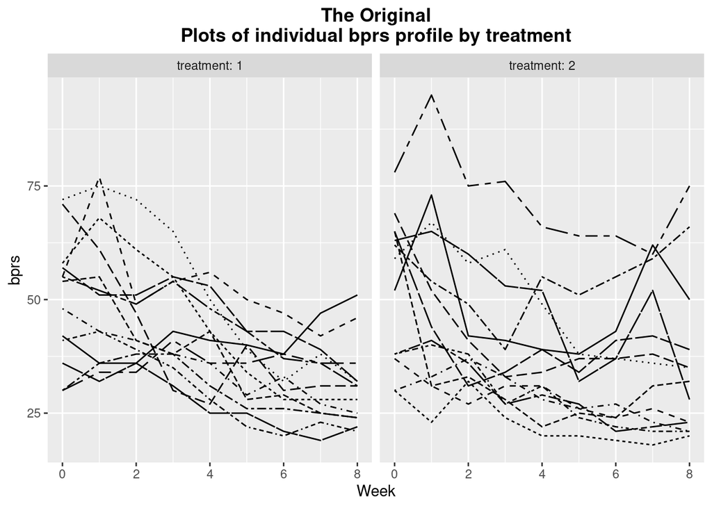

```r
# draw the plot of BPRSL with the observed bprs values
ggplot(BPRSL, aes(x = week, y = bprs, group = subject)) +
  geom_line(aes(linetype=subject)) +
  facet_grid(. ~ treatment, labeller = label_both) +
  scale_x_continuous(name = "Week") +
  scale_y_continuous(name = "bprs") +
  theme(legend.position = "none")+
  theme(plot.title = element_text(face="bold",hjust=0.5)) +
  labs(title="The Original\nPlots of individual bprs profile by treatment")
```

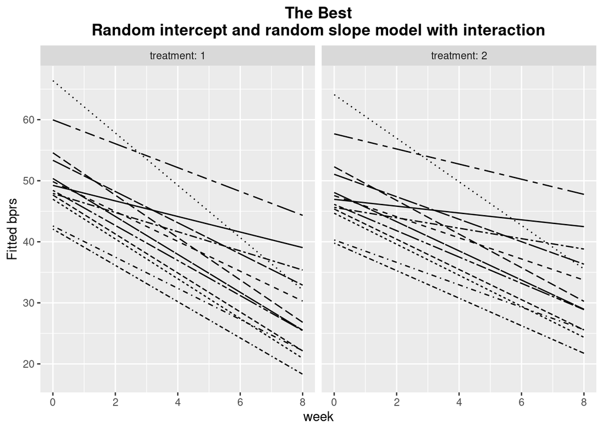

```r
# Create a vector of the fitted values
Fitted <- fitted(BPRS_ref2)
# Create a new column fitted to RATSL
BPRSL$fitted <- Fitted
# draw the plot of BPRSL with the Fitted values of bprs
ggplot(BPRSL, aes(x = week, y = fitted, group = subject)) +
  geom_line(aes(linetype = subject)) +
  facet_grid(. ~ treatment, labeller = label_both) +
  scale_x_continuous(name = "week") +
  scale_y_continuous(name = "Fitted bprs") +
  theme(legend.position = "none")+
  theme(plot.title = element_text(face="bold",hjust=0.5)) +
  labs(title="The Best\nRandom intercept and random slope model with interaction")
```

**This is it!** The best model we have (p<0.10 compared to the previous). Out of curiosity let’s also plot the previous models to see the comparison. It is very difficult to see the exact difference between the final model and the previous model without interaction. However, after that one clearly sees the difference.

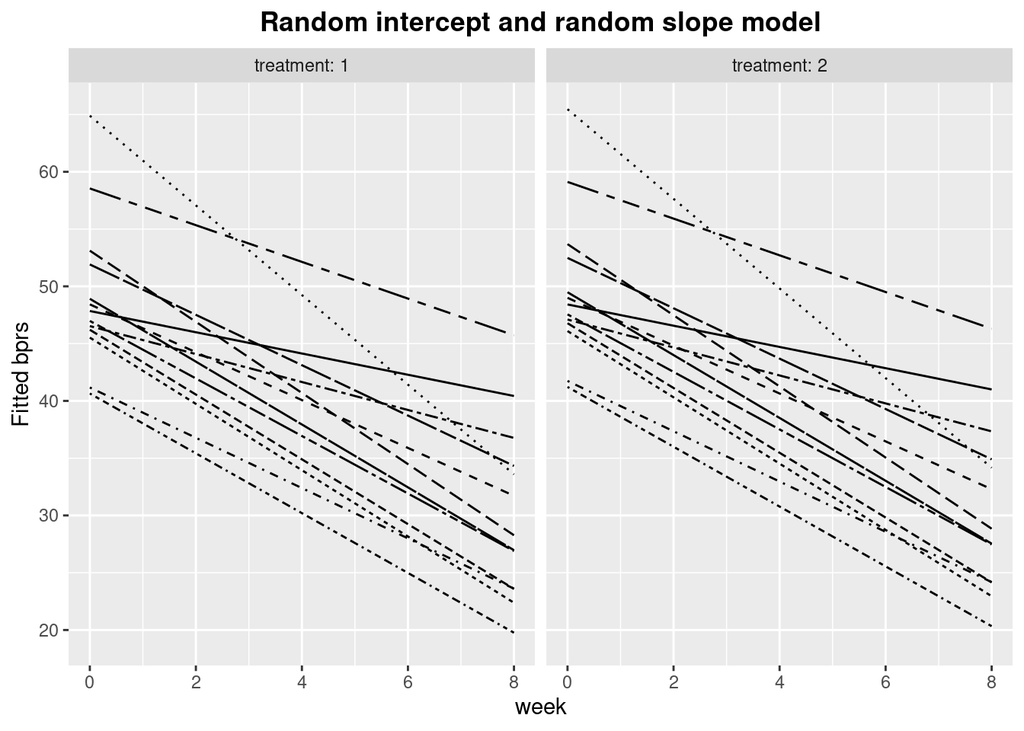

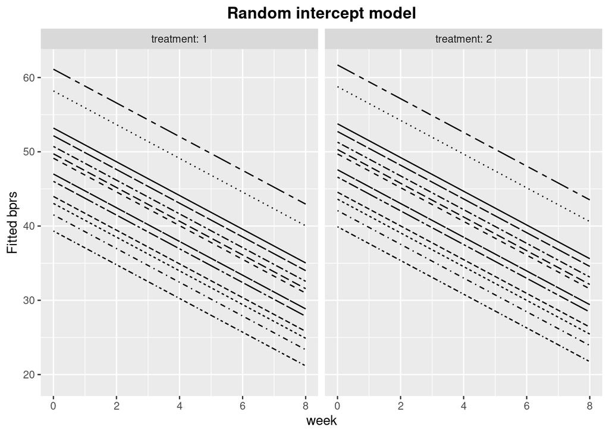

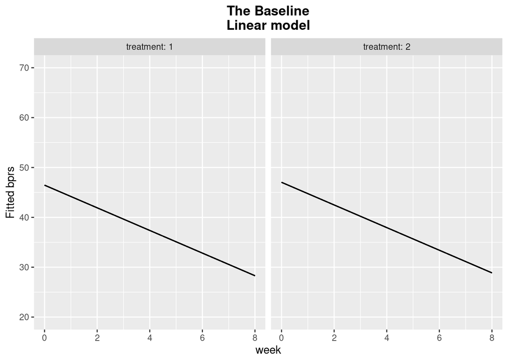